# Reduccion 20

8 actividades, costes indirectos de 3 k€/semana

# Enunciado

Considere el proyecto cuyo cuadro de prelaciones se adjunta, con la duración normal y la duración tope de cada actividad (semanas) y el coste directo (k€) de ejecutarla en cada una. Además, el proyecto tiene unos costes indirectos (oficina, alquileres, seguros) de 3 k€ por semana de duración.

1. Calcule el coste unitario de reducción (CUR) de cada actividad.

2. Determine la duración normal del proyecto y su coste total (directo más indirecto).

3. Aplique el algoritmo de Ackoff-Sasieni hasta alcanzar la duración tope del proyecto, anotando en cada paso el sobrecoste directo.

4. Construya la curva de coste total frente a duración y determine la duración de coste mínimo. ¿Qué regla de parada se deduce comparando el CUR del paso con el coste indirecto semanal?

5. ¿Por qué no se puede reducir el proyecto por debajo de su duración tope aunque queden actividades con margen de reducción?

Tabla 1: Cuadro de datos del enunciado

| activity | predecessor | duration | cap_duration | cost_normal | cost_cap |
| --- | --- | --- | --- | --- | --- |
| A | --- | 2 | 1 | 70 | 78 |
| B | --- | 6 | 3 | 30 | 33 |
| C | B | 4 | 1 | 90 | 102 |
| D | A,B | 7 | 5 | 40 | 54 |
| E | A,C | 6 | 4 | 20 | 28 |
| F | E | 8 | 6 | 50 | 54 |
| G | D,F | 4 | 4 | 90 | 90 |
| H | E | 5 | 4 | 80 | 82 |

El proyecto corresponde a la rehabilitación de una nave industrial para un taller; las actividades son las siguientes (las duraciones del cuadro están en semanas).

Tabla 2: Descripción de las actividades

|  | Descripción |
| --- | --- |
| A | Levantamiento topográfico y mediciones |
| B | Proyecto de ejecución y licencia |
| C | Desmontaje de instalaciones antiguas |
| D | Demolición de tabiquería interior |
| E | Refuerzo de la estructura metálica |
| F | Reparación de la cubierta |
| G | Solera y canalizaciones |
| H | Cerramientos y carpintería exterior |

# Resolución

## Apartado 1

1. Calcule el coste unitario de reducción (CUR) de cada actividad.

$CUR = \dfrac{\text{coste tope} - \text{coste normal}}{\text{duración normal} - \text{duración tope}}$. Las actividades cuya duración tope coincide con la normal no pueden acortarse: su CUR es infinito.

| activity | duración normal | duración tope | coste normal (k€) | coste tope (k€) | CUR = Δcoste / Δduración (k€/semana) |
| --- | --- | --- | --- | --- | --- |
| A | 2 | 1 | 70 | 78 | (78 − 70) / (2 − 1) = 8 / 1 = 8 |
| B | 6 | 3 | 30 | 33 | (33 − 30) / (6 − 3) = 3 / 3 = 1 |
| C | 4 | 1 | 90 | 102 | (102 − 90) / (4 − 1) = 12 / 3 = 4 |
| D | 7 | 5 | 40 | 54 | (54 − 40) / (7 − 5) = 14 / 2 = 7 |
| E | 6 | 4 | 20 | 28 | (28 − 20) / (6 − 4) = 8 / 2 = 4 |
| F | 8 | 6 | 50 | 54 | (54 − 50) / (8 − 6) = 4 / 2 = 2 |
| G | 4 | 4 | 90 | 90 | duración tope = normal: no se puede acortar → ∞ |
| H | 5 | 4 | 80 | 82 | (82 − 80) / (5 − 4) = 2 / 1 = 2 |

**Respuesta:** CUR (k€/semana): A = 8; B = 1; C = 4; D = 7; E = 4; F = 2; H = 2; G: ∞ (no acelerable).

## Apartado 2

2. Determine la duración normal del proyecto y su coste total (directo más indirecto).

Cálculo de los tiempos tempranos y tardíos de los sucesos y de las holguras totales paso a paso. El primer paso muestra el grafo resuelto; a partir del siguiente se calcula desde el principio (avance con los botones):

[figure not shown]

paso 0 de 26

[figure not shown]

Figura 1: Grafo PERT con las duraciones normales y el camino crítico

Tabla 3: Calendario con las duraciones normales

[figure not shown]

ninguna celda (0 de 64)

[figure not shown]

Haz clic en un número de la tabla para ver cómo se calcula.

👆 **Interactivo:** haz clic en cualquier celda de la tabla para ver cómo se calcula (otro clic la deselecciona), o usa los botones y las flechas del teclado.

| Actividad | Duración | Inicio más temprano | Fin más temprano | Inicio más tardío | Fin más tardío | H total | H libre | H independiente |
| --- | --- | --- | --- | --- | --- | --- | --- | --- |
| A | 2 | 0 | 2 | 8 | 10 | 8 | 4 | 4 |
| B | 6 | 0 | 6 | 0 | 6 | 0 | 0 | 0 |
| C | 4 | 6 | 10 | 6 | 10 | 0 | 0 | 0 |
| D | 7 | 6 | 13 | 17 | 24 | 11 | 11 | 7 |
| E | 6 | 10 | 16 | 10 | 16 | 0 | 0 | 0 |
| F | 8 | 16 | 24 | 16 | 24 | 0 | 0 | 0 |
| G | 4 | 24 | 28 | 24 | 28 | 0 | 0 | 0 |
| H | 5 | 16 | 21 | 23 | 28 | 7 | 7 | 7 |

La duración del proyecto es la de su ruta más larga. Conviene tener a la vista la duración de *todas* las rutas: al acortar la crítica, las que están a una o dos semanas de ella serán las primeras en volverse críticas y obligarán a acortar varias actividades a la vez.

Tabla 4: Duración de cada ruta con las duraciones normales

|  | actividades | duración = suma | duración | margen hasta la crítica |
| --- | --- | --- | --- | --- |
| Route_1 | A – D – G | A(2) + D(7) + G(4) = 13 | 13.0 | 15 |
| Route_2 | A – E – F – G | A(2) + E(6) + F(8) + G(4) = 20 | 20.0 | 8 |
| Route_3 | A – E – H | A(2) + E(6) + H(5) = 13 | 13.0 | 15 |
| Route_4 | B – C – E – F – G | B(6) + C(4) + E(6) + F(8) + G(4) = 28 | 28.0 | 0 |
| Route_5 | B – C – E – H | B(6) + C(4) + E(6) + H(5) = 21 | 21.0 | 7 |
| Route_6 | B – D – G | B(6) + D(7) + G(4) = 17 | 17.0 | 11 |
| Route_7 | B – E – F – G | B(6) + E(6) + F(8) + G(4) = 24 | 24.0 | 4 |
| Route_8 | B – E – H | B(6) + E(6) + H(5) = 17 | 17.0 | 11 |

Camino crítico (la ruta de mayor duración; sus actividades tienen holgura total nula):

- **B – C – E – F – G**: 6 + 4 + 6 + 8 + 4 = **28** semanas

**Duración del proyecto: 28 semanas.**

Coste directo con las duraciones normales: coste directo = A(70) + B(30) + C(90) + D(40) + E(20) + F(50) + G(90) + H(80) = 70 + 30 + 90 + 40 + 20 + 50 + 90 + 80 = **470** k€.

**Respuesta:** duración normal 28 semanas. Coste total = directo + indirecto = 470 + 3 × 28 = 470 + 84 = **554 k€**.

## Apartado 3

3. Aplique el algoritmo de Ackoff-Sasieni hasta alcanzar la duración tope del proyecto, anotando en cada paso el sobrecoste directo.

En cada paso del algoritmo de Ackoff-Sasieni se acorta una semana la ruta crítica (o las rutas críticas) eligiendo, entre las actividades críticas con margen, la combinación de menor CUR que reduzca *todas* las rutas críticas a la vez. Cuando hay varias rutas críticas sin actividades comunes baratas hay que acortar una actividad de cada una, y el coste del paso es la suma. La tabla muestra, para cada ruta, el CUR de sus actividades y su duración tras cada paso; las últimas filas, el margen de reducción que le queda a cada actividad.

Tabla 5: Algoritmo de Ackoff-Sasieni

[figure not shown]

paso -1 de 10

[figure not shown]

Algoritmo de Ackoff-Sasieni: tabla completa. Pulse «siguiente» para ver cómo se construye.

Lo que se compara en cada paso: las rutas críticas en ese momento, las opciones que acortan todas a la vez (una actividad común con margen, o una pareja con una actividad de cada ruta) con su coste, y la elegida (la más barata).

Tabla 6: Opciones consideradas en cada paso de Ackoff-Sasieni

| paso | duración | rutas críticas | opciones (coste) | elegida | coste del paso |
| --- | --- | --- | --- | --- | --- |
| 1 | 28 | Route_4 | B (1); F (2); E (4); C (4) | B | 1.0 |
| 2 | 27 | Route_4 | B (1); F (2); E (4); C (4) | B | 1.0 |
| 3 | 26 | Route_4 | B (1); F (2); E (4); C (4) | B | 1.0 |
| 4 | 25 | Route_4 | F (2); E (4); C (4) | F | 2.0 |
| 5 | 24 | Route_4 | F (2); E (4); C (4) | F | 2.0 |
| 6 | 23 | Route_4 | E (4); C (4) | C | 4.0 |
| 7 | 22 | Route_4 | E (4); C (4) | C | 4.0 |
| 8 | 21 | Route_4 | E (4); C (4) | C | 4.0 |
| 9 | 20 | Route_4 | E (4) | E | 4.0 |
| 10 | 19 | Route_4 | E (4) | E | 4.0 |

Razonamiento de cada paso (los pasos consecutivos que acortan lo mismo se agrupan): rutas críticas, opciones con su coste, cuál se elige y por qué, cuánto se reduce y hasta dónde, y el sobrecoste acumulado.

- **Pasos 1 a 3** (28 semanas → 25 semanas). Ruta crítica: Route_4 (B – C – E – F – G). Opciones que acortan la ruta crítica (CUR en k€/semana): B (1); F (2); C (4); E (4). Se elige **B** (la actividad de la ruta crítica con margen y menor CUR), la opción más barata: 1 k€ por semana. Se reducen 3 semanas: B llega a su duración tope (3 semanas). Sobrecoste: 3 × 1 = 3 k€; acumulado: **3 k€**.

- **Pasos 4 y 5** (25 semanas → 23 semanas). Ruta crítica: Route_4 (B – C – E – F – G). Opciones que acortan la ruta crítica (CUR en k€/semana): F (2); C (4); E (4). Se elige **F** (la actividad de la ruta crítica con margen y menor CUR), la opción más barata: 2 k€ por semana. Se reducen 2 semanas: F llega a su duración tope (6 semanas). Sobrecoste: 2 × 2 = 4 k€; acumulado: **7 k€**.

- **Pasos 6 a 8** (23 semanas → 20 semanas). Ruta crítica: Route_4 (B – C – E – F – G). Opciones que acortan la ruta crítica (CUR en k€/semana): C (4); E (4). Se elige **C** (la actividad de la ruta crítica con margen y menor CUR), la opción más barata: 4 k€ por semana (empata con E: cuestan lo mismo en este paso y el algoritmo toma la primera que encuentra). Se reducen 3 semanas: C llega a su duración tope (1 semana). Sobrecoste: 3 × 4 = 12 k€; acumulado: **19 k€**.

- **Pasos 9 y 10** (20 semanas → 18 semanas). Ruta crítica: Route_4 (B – C – E – F – G). Opciones que acortan la ruta crítica (CUR en k€/semana): E (4). Se elige **E** (la actividad de la ruta crítica con margen y menor CUR), la opción más barata: 4 k€ por semana. Se reducen 2 semanas: E llega a su duración tope (4 semanas). Sobrecoste: 2 × 4 = 8 k€; acumulado: **27 k€**.

**Resultado:** la duración pasa de 28 semanas a 18 semanas con un sobrecoste de 1 + 1 + 1 + 2 + 2 + 4 + 4 + 4 + 4 + 4 = **27 k€**. No puede reducirse más: en Route_4 (B – C – E – F – G) ninguna actividad tiene margen (todas están en su duración tope o no son acelerables), así que esa ruta fija la duración mínima.

| paso | actividades acortadas | sobrecoste del paso | duración | sobrecoste acumulado |
| --- | --- | --- | --- | --- |
| 1 | B | 1.0 | 27 | 1.0 |
| 2 | B | 1.0 | 26 | 2.0 |
| 3 | B | 1.0 | 25 | 3.0 |
| 4 | F | 2.0 | 24 | 5.0 |
| 5 | F | 2.0 | 23 | 7.0 |
| 6 | C | 4.0 | 22 | 11.0 |
| 7 | C | 4.0 | 21 | 15.0 |
| 8 | C | 4.0 | 20 | 19.0 |
| 9 | E | 4.0 | 19 | 23.0 |
| 10 | E | 4.0 | 18 | 27.0 |

Comprobación paso a paso: la duración de cada ruta tras cada paso es la que figura en las columnas numeradas de la tabla de Ackoff-Sasieni; tras el último paso, las rutas que empatan en la duración máxima son las críticas del proyecto reducido.

Tabla 7: Duración de cada ruta tras la reducción

|  | actividades | duración = suma | duración | crítica |
| --- | --- | --- | --- | --- |
| Route_1 | A – D – G | A(2) + D(7) + G(4) = 13 | 13.0 |  |
| Route_2 | A – E – F – G | A(2) + E(4) + F(6) + G(4) = 16 | 16.0 |  |
| Route_3 | A – E – H | A(2) + E(4) + H(5) = 11 | 11.0 |  |
| Route_4 | B – C – E – F – G | B(3) + C(1) + E(4) + F(6) + G(4) = 18 | 18.0 | sí |
| Route_5 | B – C – E – H | B(3) + C(1) + E(4) + H(5) = 13 | 13.0 |  |
| Route_6 | B – D – G | B(3) + D(7) + G(4) = 14 | 14.0 |  |
| Route_7 | B – E – F – G | B(3) + E(4) + F(6) + G(4) = 17 | 17.0 |  |
| Route_8 | B – E – H | B(3) + E(4) + H(5) = 12 | 12.0 |  |

## Apartado 4

4. Construya la curva de coste total frente a duración y determine la duración de coste mínimo. ¿Qué regla de parada se deduce comparando el CUR del paso con el coste indirecto semanal?

La tabla recorre la curva paso a paso: cada paso suma su CUR al coste directo y ahorra una semana de costes indirectos, así que el coste total varía en CUR − coste indirecto semanal.

| duración | CUR del paso | coste directo | coste indirecto | coste total | variación del total = CUR − indirecto |
| --- | --- | --- | --- | --- | --- |
| 28 | — | 470 | 84 | 554 | — |
| 27 | 1 | 471 | 81 | 552 | 1 − 3 = −2 |
| 26 | 1 | 472 | 78 | 550 | 1 − 3 = −2 |
| 25 | 1 | 473 | 75 | 548 | 1 − 3 = −2 |
| 24 | 2 | 475 | 72 | 547 | 2 − 3 = −1 |
| 23 | 2 | 477 | 69 | 546 | 2 − 3 = −1 |
| 22 | 4 | 481 | 66 | 547 | 4 − 3 = 1 |
| 21 | 4 | 485 | 63 | 548 | 4 − 3 = 1 |
| 20 | 4 | 489 | 60 | 549 | 4 − 3 = 1 |
| 19 | 4 | 493 | 57 | 550 | 4 − 3 = 1 |
| 18 | 4 | 497 | 54 | 551 | 4 − 3 = 1 |

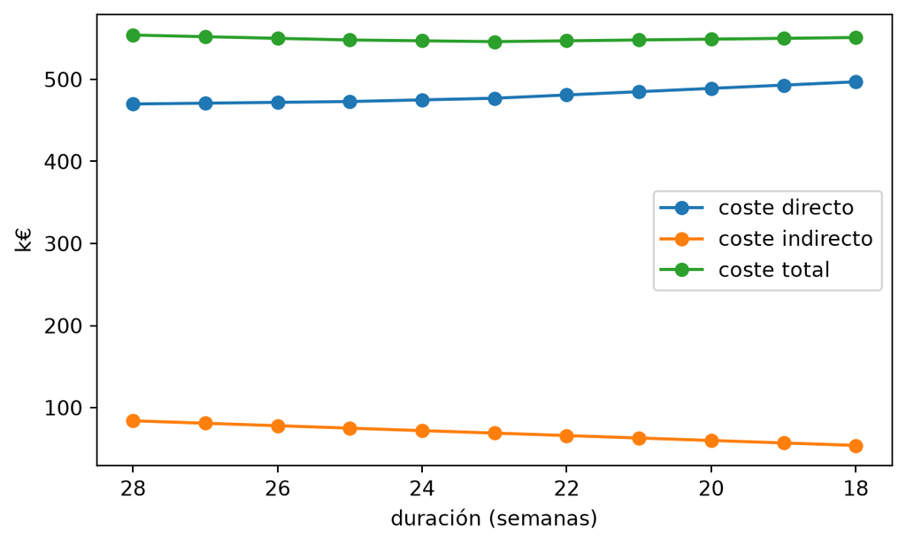

Figura 2: Curva coste-duración del proyecto

**Respuesta:** el coste total es mínimo, **546 k€**, con una duración de **23 semanas**. Regla de parada: compensa dar un paso mientras su CUR sea menor que el coste indirecto semanal (3 k€), da igual si es igual y no compensa si es mayor. Aquí los pasos 1 a 5 cuestan menos de 3 k€ y bajan el total y los pasos 6 a 10 cuestan más de 3 k€ y lo suben. Como los CUR de los pasos no decrecen, basta con parar en el primer paso cuyo CUR supera el coste indirecto semanal.

## Apartado 5

5. ¿Por qué no se puede reducir el proyecto por debajo de su duración tope aunque queden actividades con margen de reducción?

**Respuesta:** la duración tope del proyecto es 18 semanas (28 − 10 pasos). En ella, la ruta crítica Route_4 (B – C – E – F – G) no tiene ninguna actividad con margen (B en su tope, 3; C en su tope, 1; E en su tope, 4; F en su tope, 6; G no acelerable), así que no puede acortarse y fija la duración mínima del proyecto. Siguen teniendo margen A (1 semana), D (2 semanas) y H (1 semana), pero ninguna de ellas está en esa ruta: acortarlas no acorta la ruta más larga.